# UK_housing_Thuong_Pawan_Jui_Sandip-Copy1

ANALYSIS ON UK HOUSING 2012-2017

```
ABOUT THE DATASET:
```

The Price Paid Data includes information on all registered property sales in England and Wales that are sold for full market value. Address details have been truncated to the town/city level.

Explanation of 11 columns:

- **Transaction unique identifier**: A reference number which is generated automatically recording each published sale. The number is unique and will change each time a sale is recorded.
- Price: Sale price stated on the transfer deed.
- Date of Transfer: Date when the sale was completed, as stated on the transfer deed.
- Property Type:
  - D = Detached,
  - S = Semi-Detached,
  - T = Terraced,
  - F = Flats/Maisonettes,
  - O = Other
- Old/New: Indicates the age of the property and applies to all price paid transactions, residential and non-residential.
  - Y = a newly built property,
  - N = an established residential building
- Duration: Relates to the tenure:
  - F = Freehold,
  - L= Leasehold etc.
- Town/City
- District
- County
- PPD Category Type: Indicates the type of Price Paid transaction.
  - A = Standard Price Paid entry, includes single residential property sold for full market value.
  - B = Additional Price Paid entry including transfers under a power of sale/repossessions (*)
- **Record Status** monthly file only Indicates additions, changes and deletions to the records.
  - A = Addition
  - C = Change
  - D = Delete.

Notice:

- Dataset only records the above categories to describe property type, we do not separately identify bungalows. end-of-terrace properties are included in the Terraced category above.
- ‘Other’ is only valid where the transaction relates to a property type that is not covered by existing values.
- Note that where a transaction changes category type due to misallocation (as above) it will be deleted from the original category type and added to the correct category with a new transaction unique identifier.
- (*), buy-to-lets (where they can be identified by a Mortgage) and transfers to non-private individuals. Note that category B does not separately identify the transaction types stated. HM Land Registry has been collecting information on Category A transactions from January 1995. Category B transactions were identified from October 2013.
- Note that HM Land Registry does not record leases of 7 years or less in the Price Paid Dataset.
- This data was kindly released by HM Land Registry under the Open Government License 3.0. You can find their current release here.
- Data produced by HM Land Registry © Crown copyright 2017.

LOAD, INSPECT AND PROCESS DATASET

by Thuong

```python
import dask.dataframe as dd
```

```python
from dask.distributed import Client
client=Client(n_workers=2, threads_per_worker=2) # this set up 1 worker per core
client.cluster
```

```python
# importing libraries
import plotly.graph_objects as go
import chart_studio.plotly as py
import cufflinks as cf
from plotly.offline import iplot, init_notebook_mode
#--------------------------------------------#

import pandas as pd
import numpy as np
from scipy import stats

%matplotlib inline

# option for pandas to display the columns
pd.options.display.max_columns=30

# setting the notebook mode for plotly

init_notebook_mode(connected=True)
cf.go_offline(connected=True)

# setting theme in cufflinks

cf.set_config_file(theme="pearl")
#-------
from ipywidgets import interact, interactive,fixed,interact_manual
import ipywidgets as widgets
import plotly.express as px
import seaborn as sns
import matplotlib.pyplot as plt

pd.options.display.float_format = '{:,.2f}'.format
```

## Extract data from year 2012 up

```python
#data=dd.read_csv('price_paid_records.csv',parse_dates=[2],blocksize='2410MB')
```

```python
#c_data=data[data['Date of Transfer'].dt.year>2011]
```

```python
#c_data.to_csv('data2012up.csv')
```

## Load new data (year 2012 up)

```python
DATA=dd.read_csv('data2012up.csv/0.part',parse_dates=[3],blocksize='20MB')
```

## Inspect

```python
DATA.get_partition(1).compute()
```

|  | Unnamed: 0 | Transaction unique identifier | Price | Date of Transfer | Property Type | Old/New | Duration | Town/City | District | County | PPDCategory Type | Record Status - monthly file only |
| --- | --- | --- | --- | --- | --- | --- | --- | --- | --- | --- | --- | --- |
| 0 | 17792460 | {C47E3EDA-D944-4FE1-8231-97CFAE0152BE} | 322000 | 2012-06-27 | D | N | L | TELFORD | WREKIN | WREKIN | A | A |
| 1 | 17792461 | {7AA1DA53-6C57-430F-90CE-5210C7A5ABC5} | 250000 | 2012-09-28 | S | Y | F | CHINNOR | SOUTH OXFORDSHIRE | OXFORDSHIRE | A | A |
| 2 | 17792462 | {05694E0B-40A6-498A-A9E6-5210D007374C} | 169000 | 2012-01-20 | F | N | L | PORTSMOUTH | PORTSMOUTH | PORTSMOUTH | A | A |
| 3 | 17792463 | {DFAFD68C-AFDB-4A17-83DC-5210DCD6781D} | 225000 | 2012-03-23 | D | N | F | NORTHAMPTON | NORTHAMPTON | NORTHAMPTONSHIRE | A | A |
| 4 | 17792464 | {B739C3A1-5172-41A0-9358-559FB021709D} | 125000 | 2012-06-13 | T | N | F | ROCHESTER | MEDWAY | MEDWAY | A | A |
| ... | ... | ... | ... | ... | ... | ... | ... | ... | ... | ... | ... | ... |
| 179574 | 17972034 | {A6A0119F-EFD4-4079-AF34-486103ED137B} | 89000 | 2012-12-12 | T | N | F | BIRMINGHAM | BIRMINGHAM | WEST MIDLANDS | A | A |
| 179575 | 17972035 | {B2BC10F7-14E8-48BC-B714-486103F5C100} | 140000 | 2012-03-08 | S | N | F | EXMOUTH | EAST DEVON | DEVON | A | A |
| 179576 | 17972036 | {CD490E17-FB17-45A4-A8CA-48610635A27B} | 150000 | 2012-04-26 | F | N | L | YORK | YORK | YORK | A | A |
| 179577 | 17972037 | {92DE07BB-4D48-43F5-9C26-486111BFBECD} | 80000 | 2012-08-10 | S | N | F | DONCASTER | DONCASTER | SOUTH YORKSHIRE | A | A |
| 179578 | 17972038 | {7B79C472-FB84-4FD2-B1FF-48611FB754AB} | 112000 | 2012-05-04 | F | N | L | IPSWICH | SUFFOLK COASTAL | SUFFOLK | A | A |

179579 rows × 12 columns

```python
DATA.isna().sum().sum().compute()
```

```
0
```

```python
DATA.shape[0].compute(),DATA.shape[1]
```

```
(4876426, 12)
```

```python
DATA.dtypes
```

```
Unnamed: 0                                    int64
Transaction unique identifier                object
Price                                         int64
Date of Transfer                     datetime64[ns]
Property Type                                object
Old/New                                      object
Duration                                     object
Town/City                                    object
District                                     object
County                                       object
PPDCategory Type                             object
Record Status - monthly file only            object
dtype: object
```

```python
# Notice that Date of Transfer columns contain duplicate values, because several transactions can be made on one date.
```

```python
DATA['Date of Transfer'].unique().compute()
```

```
0      2012-09-28
1      2012-07-18
2      2012-04-25
3      2012-10-25
4      2012-04-13
          ...
1998   2017-03-04
1999   2017-04-09
2000   2017-03-05
2001   2017-01-28
2002   2017-04-08
Name: Date of Transfer, Length: 2003, dtype: datetime64[ns]
```

```python
DATA['Property Type'].unique().compute()
```

```
0    S
1    D
2    T
3    F
4    O
Name: Property Type, dtype: object
```

```python
DATA['Price'].describe().compute()  # PRICE OUTLINER! DANGER!!!!!
```

```
count    4,876,426.00
mean       283,631.87
std        773,019.82
min              1.00
25%        146,000.00
50%        224,995.00
75%        350,000.00
max     98,900,000.00
Name: Price, dtype: float64
```

```python
#drop duplicate row if any, but no duplicate, may take time to run
#DATA.drop_duplicates()
```

## Remove illogical price

Reason: https://www.dailymail.co.uk/property/article-6628333/Cheapest-properties-sale-cost-15-month.html

```python
DATA=DATA[DATA.Price>=4000]
```

```python
DATA.head()
```

|  | Unnamed: 0 | Transaction unique identifier | Price | Date of Transfer | Property Type | Old/New | Duration | Town/City | District | County | PPDCategory Type | Record Status - monthly file only |
| --- | --- | --- | --- | --- | --- | --- | --- | --- | --- | --- | --- | --- |
| 0 | 17612922 | {BD0D075D-7818-47B3-9657-7651CBD02219} | 155000 | 2012-09-28 | S | N | F | YORK | YORK | YORK | A | A |
| 1 | 17612923 | {0FF70080-C8EA-4DDC-9C19-7651D9B540CC} | 264000 | 2012-07-18 | D | N | F | HAYLING ISLAND | HAVANT | HAMPSHIRE | A | A |
| 2 | 17612924 | {80CC2177-EDBE-4ABB-9EAA-7651DAA0E4EE} | 20000 | 2012-04-25 | T | N | F | HULL | CITY OF KINGSTON UPON HULL | CITY OF KINGSTON UPON HULL | A | A |
| 3 | 17612925 | {076B2969-50D6-4659-8956-7651ECAAB904} | 89950 | 2012-10-25 | S | N | F | WORKSOP | BASSETLAW | NOTTINGHAMSHIRE | A | A |
| 4 | 17612926 | {9A6B1BBC-3522-4B44-9FD6-765202F73E28} | 168000 | 2012-04-13 | S | N | F | TORQUAY | TORBAY | TORBAY | A | A |

```python
DATA.tail()
```

|  | Unnamed: 0 | Transaction unique identifier | Price | Date of Transfer | Property Type | Old/New | Duration | Town/City | District | County | PPDCategory Type | Record Status - monthly file only |
| --- | --- | --- | --- | --- | --- | --- | --- | --- | --- | --- | --- | --- |
| 31306 | 22489343 | {4C4EE000-291A-1854-E050-A8C063054F34} | 175000 | 2017-02-20 | S | N | F | LEEDS | LEEDS | WEST YORKSHIRE | A | A |
| 31307 | 22489344 | {4C4EE000-291B-1854-E050-A8C063054F34} | 586945 | 2017-02-15 | D | N | F | WETHERBY | LEEDS | WEST YORKSHIRE | A | A |
| 31308 | 22489345 | {4C4EE000-291C-1854-E050-A8C063054F34} | 274000 | 2017-02-24 | D | N | L | HUDDERSFIELD | KIRKLEES | WEST YORKSHIRE | A | A |
| 31309 | 22489346 | {4C4EE000-291D-1854-E050-A8C063054F34} | 36000 | 2017-02-22 | T | N | F | HALIFAX | CALDERDALE | WEST YORKSHIRE | A | A |
| 31310 | 22489347 | {4C4EE000-291E-1854-E050-A8C063054F34} | 145000 | 2017-03-03 | T | N | F | LEEDS | LEEDS | WEST YORKSHIRE | A | A |

```python
DATA.dtypes
```

```
Unnamed: 0                                    int64
Transaction unique identifier                object
Price                                         int64
Date of Transfer                     datetime64[ns]
Property Type                                object
Old/New                                      object
Duration                                     object
Town/City                                    object
District                                     object
County                                       object
PPDCategory Type                             object
Record Status - monthly file only            object
dtype: object
```

```python
DATA.shape[0].compute()
```

```
4874262
```

## Drop uncessary columns

```python
DATA.columns
```

```
Index(['Unnamed: 0', 'Transaction unique identifier', 'Price',
       'Date of Transfer', 'Property Type', 'Old/New', 'Duration', 'Town/City',
       'District', 'County', 'PPDCategory Type',
       'Record Status - monthly file only'],
      dtype='object')
```

```python
data_group=DATA[['Date of Transfer', 'Price','Property Type', 'Old/New', 'Duration', 'Town/City',
       'District', 'County', 'PPDCategory Type']]
```

```python
data_group.head()
```

|  | Date of Transfer | Price | Property Type | Old/New | Duration | Town/City | District | County | PPDCategory Type |
| --- | --- | --- | --- | --- | --- | --- | --- | --- | --- |
| 0 | 2012-09-28 | 155000 | S | N | F | YORK | YORK | YORK | A |
| 1 | 2012-07-18 | 264000 | D | N | F | HAYLING ISLAND | HAVANT | HAMPSHIRE | A |
| 2 | 2012-04-25 | 20000 | T | N | F | HULL | CITY OF KINGSTON UPON HULL | CITY OF KINGSTON UPON HULL | A |
| 3 | 2012-10-25 | 89950 | S | N | F | WORKSOP | BASSETLAW | NOTTINGHAMSHIRE | A |
| 4 | 2012-04-13 | 168000 | S | N | F | TORQUAY | TORBAY | TORBAY | A |

```python
data_group.dtypes
```

```
Date of Transfer    datetime64[ns]
Price                        int64
Property Type               object
Old/New                     object
Duration                    object
Town/City                   object
District                    object
County                      object
PPDCategory Type            object
dtype: object
```

## Change columns name to more concise versions

```python
new_cols=['Date','Price','Property Type','Old/New','Duration','Town/City','District','County','Price Method']
data_group_new=data_group.rename(columns=dict(zip(data_group.columns,new_cols)))
```

```python
data_group_new.head()
```

|  | Date | Price | Property Type | Old/New | Duration | Town/City | District | County | Price Method |
| --- | --- | --- | --- | --- | --- | --- | --- | --- | --- |
| 0 | 2012-09-28 | 155000 | S | N | F | YORK | YORK | YORK | A |
| 1 | 2012-07-18 | 264000 | D | N | F | HAYLING ISLAND | HAVANT | HAMPSHIRE | A |
| 2 | 2012-04-25 | 20000 | T | N | F | HULL | CITY OF KINGSTON UPON HULL | CITY OF KINGSTON UPON HULL | A |
| 3 | 2012-10-25 | 89950 | S | N | F | WORKSOP | BASSETLAW | NOTTINGHAMSHIRE | A |
| 4 | 2012-04-13 | 168000 | S | N | F | TORQUAY | TORBAY | TORBAY | A |

```python
data_group_new.dtypes
```

```
Date             datetime64[ns]
Price                     int64
Property Type            object
Old/New                  object
Duration                 object
Town/City                object
District                 object
County                   object
Price Method             object
dtype: object
```

ANALYSIS PART I: DESCRIPTVE

by Pawan

To remove outliers we have decided to drop all the rows which price is less than 4000. Anything over 4000, we are keeping in pur data. In our data sets there were over 2000 inputs were outliers. After removing outlier, input of our data is decresed by 2000 rows.

```python
data_group_new.Price.describe().compute()
```

```
count    4,874,262.00
mean       283,757.03
std        773,168.57
min          4,000.00
25%        146,500.00
50%        225,000.00
75%        350,000.00
max     98,900,000.00
Name: Price, dtype: float64
```

There are five kinds of unique property types:

- D = Detached,
- S = Semi-Detached,
- T = Terraced,
- F = Flats/Maisonettes,
- O = Other

```python
data_group_new['Property Type'].describe().compute()
```

```
unique          5
count     4874262
top             T
freq      1411594
Name: Property Type, dtype: object
```

```python
# after removing outliers
data_group_new['Property Type'].unique().compute()
```

```
0    S
1    D
2    T
3    F
4    O
Name: Property Type, dtype: object
```

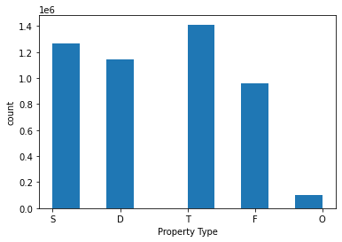

```python
# after removing outliers
plt.hist(data_group_new['Property Type'].compute())
plt.xlabel('Property Type')
plt.ylabel('count')
```

```python
data_group_new['Property Type'].value_counts().compute()
```

```
T    1411594
S    1266345
D    1141107
F     956980
O      98236
Name: Property Type, dtype: int64
```

**From here we can see how many properties are newely built.**

Indicates the age of the property and applies to all price paid transactions, residential and non-residential.

- Y = a newly built property,
- N = an established residential building

```python
# after removing outliers
data_group_new['Old/New'].describe().compute()
```

```
unique          2
count     4874262
top             N
freq      4389297
Name: Old/New, dtype: object
```

```python
# after removing outliers
data_group_new['Old/New'].value_counts().compute()
```

```
N    4389297
Y     484965
Name: Old/New, dtype: int64
```

**This column show the duration of each property tenant holds**

Relates to the tenure:

- F = Freehold,
- L= Leasehold

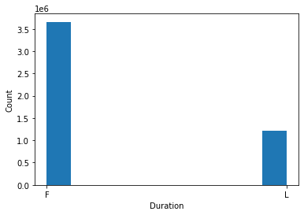

```python
plt.hist(data_group_new['Duration'].compute())
plt.xlabel('Duration')
plt.ylabel('Count')
```

```python
# After removing outliers
data_group_new['Duration'].describe().compute()
```

```
unique          2
count     4874262
top             F
freq      3658226
Name: Duration, dtype: object
```

```python
# after removing outliers
data_group_new['Duration'].value_counts().compute()
```

```
F    3658226
L    1216036
Name: Duration, dtype: int64
```

This column shows the Town/City where property are located. And shows there are 1151 Town/City where property are situated in UK.

```python
# after removing outliers
data_group_new['Town/City'].describe().compute()
```

```
unique       1151
count     4874262
top        LONDON
freq       381726
Name: Town/City, dtype: object
```

```python
# After outliers
data_group_new['Town/City'].value_counts().compute()
```

```
LONDON           381726
BRISTOL           79027
MANCHESTER        76761
BIRMINGHAM        67986
NOTTINGHAM        65025
                  ...
NEWCASTLETON          9
MINDRUM               9
GATWICK               5
GRETNA                1
PORT DINORWIC         1
Name: Town/City, Length: 1151, dtype: int64
```

```python
# After outliers
data_group_new['District'].describe().compute()
```

```
unique           349
count        4874262
top       BIRMINGHAM
freq           67456
Name: District, dtype: object
```

```python
# after removing outliers
data_group_new['District'].value_counts().compute()
```

```
BIRMINGHAM         67456
LEEDS              64669
CORNWALL           55300
WILTSHIRE          46273
CITY OF BRISTOL    41572
                   ...
MERTHYR TYDFIL      3806
WEST SOMERSET       3566
CITY OF LONDON      1815
ISLES OF SCILLY      108
MACCLESFIELD           1
Name: District, Length: 349, dtype: int64
```

```python
# after removing outliers
data_group_new['County'].describe().compute()
```

```
unique               113
count            4874262
top       GREATER LONDON
freq              630522
Name: County, dtype: object
```

```python
# after removing the outliers
data_group_new['County'].value_counts().compute()
```

```
GREATER LONDON        630522
GREATER MANCHESTER    207297
WEST MIDLANDS         181388
WEST YORKSHIRE        176696
KENT                  146286
                       ...
BLAENAU GWENT           4131
RUTLAND                 3956
MERTHYR TYDFIL          3806
ISLES OF SCILLY          108
CHESHIRE                   1
Name: County, Length: 113, dtype: int64
```

**This cloumn shows how the payment type, there are two types of payments A and B**

Price Method: Indicates the type of Price Paid transaction.

- A = Standard Price Paid entry, includes single residential property sold for full market value.
- B = Additional Price Paid entry including transfers under a power of sale/repossessions (*)

```python
# After removing the outliers
data_group_new['Price Method'].describe().compute()
```

```
unique          2
count     4874262
top             A
freq      4528850
Name: Price Method, dtype: object
```

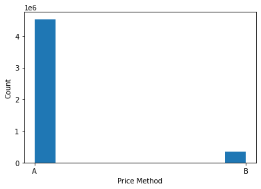

```python
# after removing the outliers
plt.hist(data_group_new['Price Method'].compute())
plt.xlabel('Price Method')
plt.ylabel('Count')
```

```python
# after removing the outliers
data_group_new['Price Method'].value_counts().compute()
```

```
A    4528850
B     345412
Name: Price Method, dtype: int64
```

ANALYSIS PART II: ANALYSING PRICE THROUGH TIME

by Jui & Sandip

```python
jui=data_group_new[['Date','Price']].set_index('Date').compute()
```

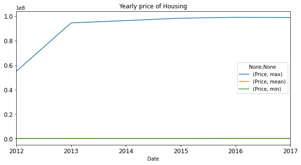

```python
temp =jui.resample('Y').agg(['max','mean','min'])
temp.plot(figsize=(10,5), title = 'Yearly price of Housing', fontsize = 12)
```

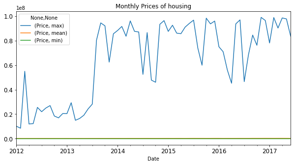

```python
temp =jui.resample('M').agg(['max','mean','min'])
temp.plot(figsize=(10,5), title = 'Monthly Prices of housing', fontsize = 12)
```

## Checking the Mean price of housing on the basis of Years, Months and Days and visualizing

```python
data_group3=data_group_new.set_index('Date').compute()
```

### Yearly basis

```python
data_group3.Price.resample('Y').mean().iplot(kind="bar",
                                             title="Mean price of housing for each years")
```

[interactive chart not shown]

**This visualization shows the average housing price on the basis of years for the dataset. There has been no decrease in the average housing price between the years 2012 to 2017 as you can see from the graph. But the increase is also steady since real state business tends to increase every year.**

### Daily basis

```python
data_group3.Price.resample('D').mean().iplot(kind='line',title="Mean price on the basis of Days")
```

[interactive chart not shown]

**This graph shows the price of housing on the daily basis which is why it is difficult to plot graphically because daily datas are too long to plot here. So, looking at this graph we know this is kind of messy but we just wanted to see the trend of days.For better understanding we can zoom in on specific period to check the trend in that period on day basis.**

### Monthly Basis

```python
data_group3.resample('M').Price.mean().iplot(kind="line",title="Monthly price for each year")
```

[interactive chart not shown]

Here is the line graph presenting the monthly average price for housing. As you can see, there has been quite ups and downs in the price on different months.

## Maximum Price trends from 2012 to 2017

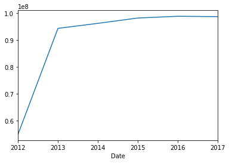

```python
data_group3.resample('Y').Price.max().plot(kind='line',y="Price");
```

## Percentage change in Sales growth from previous years

```python
a=data_group3.resample('Y')['Price'].sum().pct_change().iplot(kind='line',width=5)
```

[interactive chart not shown]

*This line graph shows the trend in the change in sales growth from previous years. Here, we can see that percentage change in sales growth have been decreasing throughout the years.The most decrease has been seen from the years 2016 to 2017 which is in negative.*

ANALYSIS PART III: GAINING INSIGHT FROM CATEGORICAL VARIABLES

by Thuong

```python
data_group_new.head()
```

|  | Date | Price | Property Type | Old/New | Duration | Town/City | District | County | Price Method |
| --- | --- | --- | --- | --- | --- | --- | --- | --- | --- |
| 0 | 2012-09-28 | 155000 | S | N | F | YORK | YORK | YORK | A |
| 1 | 2012-07-18 | 264000 | D | N | F | HAYLING ISLAND | HAVANT | HAMPSHIRE | A |
| 2 | 2012-04-25 | 20000 | T | N | F | HULL | CITY OF KINGSTON UPON HULL | CITY OF KINGSTON UPON HULL | A |
| 3 | 2012-10-25 | 89950 | S | N | F | WORKSOP | BASSETLAW | NOTTINGHAMSHIRE | A |
| 4 | 2012-04-13 | 168000 | S | N | F | TORQUAY | TORBAY | TORBAY | A |

## How Property, Status, Duration, Location tell us about housing price in UK from 2012 to 2017?

```python
Property=data_group_new[['Price','Property Type']].groupby(['Property Type']).agg(['max','mean','min']).compute()
Status=data_group_new[['Price','Old/New']].groupby(['Old/New']).agg(['max','mean','min']).compute()
Duration=data_group_new[['Price','Duration']].groupby(['Duration']).agg(['max','mean','min']).compute()
County=data_group_new[['Price','County']].groupby(['County']).agg(['max','mean','min']).compute()
Price_Method=data_group_new[['Price','Price Method']].groupby(['Price Method']).agg(['max','mean','min']).compute()
```

```python
Property.rename({'D':'Detached', 'S':'Semi-Detached','T':'Terraced','F':'Flats/Maisonettes','O':'Other'},inplace=True)
Status.rename({'Y': 'a newly built property', 'N':'an established residential building'},inplace=True)
Duration.rename({'F':'Freehold','L': 'Leasehold'},inplace=True)
Price_Method.rename({'A':' Standard Price Paid entry','B': 'Additional Price Paid entry'},inplace=True)
```

click in the legend box on the right side of the graph to disable/enable aspects of prices.

```python
Property.iplot(kind='bar')
```

[interactive chart not shown]

```python
Status.iplot(kind='bar')
```

[interactive chart not shown]

```python
Duration.iplot(kind='bar')
```

[interactive chart not shown]

```python
Price_Method.iplot(kind='bar')
```

[interactive chart not shown]

```python
County.iplot(kind='bar')
```

[interactive chart not shown]

**Property Type**: Regular types (Detached, Flats/Maisonettes, Semi-detached, Terraced) are relatively simmilar prices; but Other types of housing are expensive in the UK. Using data removed outlinere, in regular types, Detached house is the most expensive, and the most affordable one is Terraced.  
**Status (Old/New)**: There is not clear different between the old and new properties.  
**Duration**: Freehold seems to be slightly more expensive to get than Leasehold  
**County**: Price can be very diffferent between different counties, which suggest that location can influence much to the price of housing. The most expensive place to live probably in Greater London (top price housing), then Windsor and Maidenhead, and the third runner up position is Surrey.  
**Price Method**: Different pricing methods influence on the price.

# Time Series Analysis On Categorical variables and Price

```python
data_group_new.head()
```

|  | Date | Price | Property Type | Old/New | Duration | Town/City | District | County | Price Method |
| --- | --- | --- | --- | --- | --- | --- | --- | --- | --- |
| 0 | 2012-09-28 | 155000 | S | N | F | YORK | YORK | YORK | A |
| 1 | 2012-07-18 | 264000 | D | N | F | HAYLING ISLAND | HAVANT | HAMPSHIRE | A |
| 2 | 2012-04-25 | 20000 | T | N | F | HULL | CITY OF KINGSTON UPON HULL | CITY OF KINGSTON UPON HULL | A |
| 3 | 2012-10-25 | 89950 | S | N | F | WORKSOP | BASSETLAW | NOTTINGHAMSHIRE | A |
| 4 | 2012-04-13 | 168000 | S | N | F | TORQUAY | TORBAY | TORBAY | A |

```python
data3=data_group_new.categorize(columns=['Property Type','Old/New','Duration','County','Price Method'])
```

### Looking at different property type's price through years/months

```python
viz1=data3.pivot_table(index='Date',columns='Property Type',values='Price',aggfunc='mean').compute()
viz1.rename({'D':'Detached', 'S':'Semi-Detached','T':'Terraced','F':'Flats/Maisonettes','O':'Other'},axis=1,inplace=True)
```

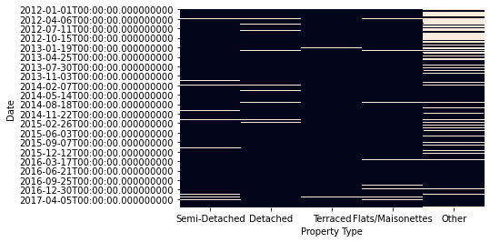

```python
sns.heatmap(viz1.isnull(),cbar=False)
```

```python
viz1.drop('Other',axis=1,inplace=True)
viz1.dropna(inplace=True)
```

```python
viz1.head()
```

| Property Type Date | Semi-Detached | Detached | Terraced | Flats/Maisonettes |
| --- | --- | --- | --- | --- |
| 2012-01-02 | 171,575.00 | 235,666.67 | 147,749.58 | 146,737.50 |
| 2012-01-03 | 176,143.57 | 332,108.52 | 161,845.34 | 245,627.12 |
| 2012-01-04 | 217,285.57 | 339,520.07 | 188,954.11 | 207,488.54 |
| 2012-01-05 | 233,865.25 | 349,180.84 | 228,184.72 | 243,759.31 |
| 2012-01-06 | 196,675.47 | 314,451.20 | 197,356.49 | 219,022.38 |

```python
viz1.resample('M').mean().iplot()
```

[interactive chart not shown]

Price went up almost all type of property. We can see Detached is the higest, then Flats, and then other types are more close to each other in the low level price. Exceptional time 2013 to 2014, position of Semi-detached and Terraced exchanged.

### Looking at prices of housing accross Counties yearly/monthly

```python
viz2=data3.pivot_table(index='Date',columns='County',values='Price',aggfunc='mean').compute()
```

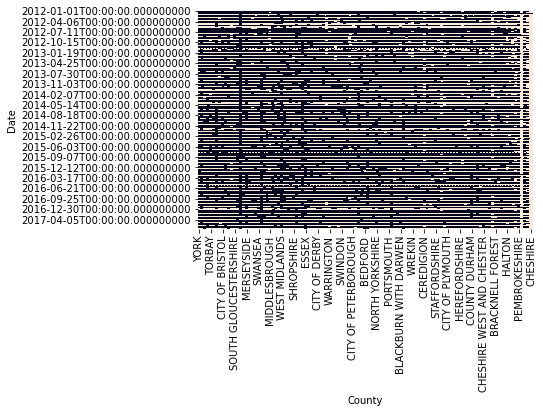

```python
sns.heatmap(viz2.isnull(),cbar=False)
```

On the heatmap shows the missing value, we can see that missing value are abundant (especially last columns). Even if we remove the last columns, data stills contains too much missing values. At this end, we decide not to go further to explore as intended.

## Finding the price differences through time between Old/New housing

```python
viz3=data3.pivot_table(index='Date',columns='Old/New',values='Price',aggfunc='mean').compute()
viz3.rename({'Y': 'a newly built property', 'N':'an established residential building'},axis=1,inplace=True)
```

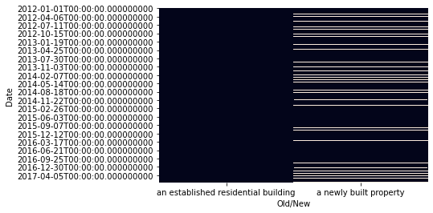

```python
sns.heatmap(viz3.isnull(),cbar=False)
```

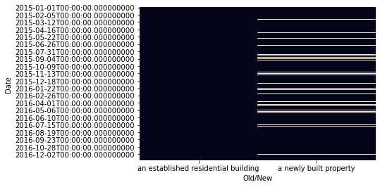

```python
sns.heatmap(viz3['2015-01-01':'2016-12-30'].isnull(),cbar=False)
```

```python
viz3_=viz3['2015-01-01':'2016-12-30']
viz3_.dropna(inplace=True)
```

```python
viz3_.resample('M').mean().iplot()
```

[interactive chart not shown]

Previously, we see in general view mean value of price between Old and New Housing, there is quite flat comparision. In this view, by using time series, we can zoom in to see the difference. Although generally talking, price of Old and New Housing is not much different, but price of Old and New housing can be substaintially different in particular time (months).

## Time Series analysis of price of different Duration of holding property:

```python
viz4=data3.pivot_table(index='Date',columns='Duration',values='Price',aggfunc='mean').compute()
```

```python
viz4.rename({'F':'Freehold', 'L':'Leasehold'},axis=1,inplace=True)
```

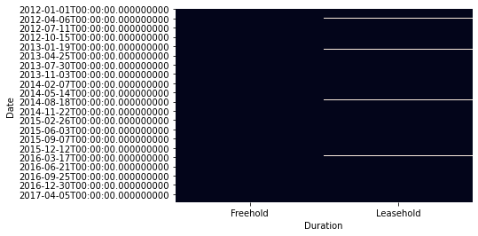

```python
sns.heatmap(viz4.isnull(),cbar=False)
```

```python
viz4.dropna(inplace=True)
```

```python
viz4.resample('M').mean().iplot()
```

[interactive chart not shown]

Previously we see difference between different Duration. In this view, we can see more the different prices at different months of the year 2012-2017.

ANALYSIS PART IV: RECOMMENDATIONS FOR INVESTORS

by Thuong

# Where can you buy estates if you have a certain budget range?

Previously analysed, we know that different counties influence on price. A certain budget will limit places to invest. Using county as a starting point to know where budget is enough to buy a property, or the likely of the chance (several or many property) we can buy within our budget. Let's break it down here:  
1. Where is our budget enough to buy a property?  
*This question is answered by comparing our budget with the minimum housing price in a county.*  
2. Where does our budget likely have options to buy property?  
*This question is answered by comparing our budget with the mean housing price in a county.*  
3. Where is our budget enough to buy even the most expensive one?  
*This question is answered by comparing our budget with the maximum housing price in a county.*  
Notice: It would make more sense to take price of the latest year, so we limit the data for this part in 2017.

```python
d1=data_group_new.compute()
```

```python
county=d1[d1.Date.dt.year==2017]
```

```python
county
```

|  | Date | Price | Property Type | Old/New | Duration | Town/City | District | County | Price Method |
| --- | --- | --- | --- | --- | --- | --- | --- | --- | --- |
| 15121 | 2017-02-17 | 325000 | T | Y | F | EASTLEIGH | EASTLEIGH | HAMPSHIRE | A |
| 15122 | 2017-01-30 | 424950 | D | Y | F | FARNBOROUGH | RUSHMOOR | HAMPSHIRE | A |
| 15123 | 2017-03-01 | 499950 | D | Y | F | SOUTHAMPTON | EASTLEIGH | HAMPSHIRE | A |
| 15124 | 2017-03-06 | 410000 | T | N | F | FARNBOROUGH | RUSHMOOR | HAMPSHIRE | A |
| 15125 | 2017-02-17 | 184500 | S | N | L | SOUTHAMPTON | SOUTHAMPTON | SOUTHAMPTON | A |
| ... | ... | ... | ... | ... | ... | ... | ... | ... | ... |
| 31306 | 2017-02-20 | 175000 | S | N | F | LEEDS | LEEDS | WEST YORKSHIRE | A |
| 31307 | 2017-02-15 | 586945 | D | N | F | WETHERBY | LEEDS | WEST YORKSHIRE | A |
| 31308 | 2017-02-24 | 274000 | D | N | L | HUDDERSFIELD | KIRKLEES | WEST YORKSHIRE | A |
| 31309 | 2017-02-22 | 36000 | T | N | F | HALIFAX | CALDERDALE | WEST YORKSHIRE | A |
| 31310 | 2017-03-03 | 145000 | T | N | F | LEEDS | LEEDS | WEST YORKSHIRE | A |

374429 rows × 9 columns

```python
d2=county.groupby(['County'])['Price'].agg(['max','mean','min'])
```

```python
d2
```

| County | max | mean | min |
| --- | --- | --- | --- |
| BATH AND NORTH EAST SOMERSET | 11450000 | 419,340.91 | 9500 |
| BEDFORD | 25573313 | 350,063.67 | 4000 |
| BLACKBURN WITH DARWEN | 9635000 | 170,595.64 | 5250 |
| BLACKPOOL | 12619992 | 139,541.88 | 5250 |
| BLAENAU GWENT | 520000 | 90,423.47 | 27000 |
| ... | ... | ... | ... |
| WOKINGHAM | 16640000 | 465,418.05 | 76728 |
| WORCESTERSHIRE | 24521657 | 274,165.89 | 4800 |
| WREKIN | 8750000 | 186,935.30 | 14901 |
| WREXHAM | 2319791 | 183,091.39 | 5000 |
| YORK | 34000000 | 326,898.67 | 5710 |

112 rows × 3 columns

```python
fig=px.bar(d2,x='max',y=d2.index,color='max',height=1000)
fig.update_xaxes(rangeslider_visible=True)
fig.show()
```

[interactive chart not shown]

```python
fig=px.bar(d2,x='min',y=d2.index,color='min',height=1000)
fig.update_xaxes(rangeslider_visible=True)
fig.show()
```

[interactive chart not shown]

```python
fig=px.bar(d2,x='mean',y=d2.index,color='mean',height=1000)
fig.update_xaxes(rangeslider_visible=True)
fig.show()
```

[interactive chart not shown]

Scenario: you have max budget range 100k to 150k. Options to buy open to you as below: (using slider to choose min, mean,max value, and range slider in x-axis to specify your budget)  
1. Within your budget, you can buy the minimum (cheapest) estates in all county in England, Wales because all minium prices falls below 100k. However, minimum prices is limited, your options to buy is not likely confirmed.  
2. Looking at slider for mean price, within your budget you can likely buy and have options to buy in many counties as specify in column that go below 150k threadhold: **Blackpool, Blaenau Gwent, Caerphylly, County Durham, Hartelpool, Merthyr Tydfil, Diddlesbrough, North East Lincolnshire, Redcar and cleverland, Rhondda Cynon Taff,Torfaen.**  
3. if you target the luxury segment, you may be interested in seeing if where you budget can buy the most expensive estate? changing slider of the graph to 'max', and narrow down the x-axes lable to 150k, we can see that the budget is not enough to buy the most expensive housing in any county.

# Where could be the place to maximize profit?

In this parts, we want to develop further the ideas from the previous part which let you know where you can invest within your budget. The next challenge is to know among those selected counties, which county price has a high chance to increase. To answer this, we will look through the growth of price in the past 5 years in each county.

```python
t='Blackpool, Blaenau Gwent, CaerphIlly, County Durham, Hartlepool, Merthyr Tydfil, Middlesbrough, North East Lincolnshire, Redcar and cleveland, Rhondda Cynon Taff, Torfaen'
```

```python
viz2_c=viz2.resample('5Y').mean()
viz2_5=(viz2_c.loc['2017-12-31']-viz2_c.loc['2012-12-31'])/viz2_c.loc['2012-12-31']
px.bar(viz2_5[t.upper().split(', ')],labels={'value':'Percentage growth 2012 to 2017'})
```

[interactive chart not shown]

Looking at 5 years period, the TOP 3 strongest growth was in RHONDDA CYNON TAFF, then MERTHUR TYDFIL, and then CAERPHILLY.  
However, one concern is that we want to know how stable is the growth, which leading to the next analysis of looking yearly and monthly growth.

```python
viz2_c=viz2.resample('Y').mean()
viz2_f=viz2_c[t.upper().split(', ')]
fig=px.line(viz2_f[['CAERPHILLY','MERTHYR TYDFIL','RHONDDA CYNON TAFF']])
fig.update_xaxes(rangeslider_visible=True)
fig.show()
```

[interactive chart not shown]

```python
viz2_f
```

| County Date | BLACKPOOL | BLAENAU GWENT | CAERPHILLY | COUNTY DURHAM | HARTLEPOOL | MERTHYR TYDFIL | MIDDLESBROUGH | NORTH EAST LINCOLNSHIRE | REDCAR AND CLEVELAND | RHONDDA CYNON TAFF | TORFAEN |
| --- | --- | --- | --- | --- | --- | --- | --- | --- | --- | --- | --- |
| 2012-12-31 | 104,179.62 | 75,529.82 | 113,922.29 | 117,721.32 | 116,028.12 | 94,259.67 | 114,748.77 | 114,159.49 | 121,864.65 | 98,026.91 | 128,811.97 |
| 2013-12-31 | 105,111.04 | 77,130.80 | 117,921.16 | 132,415.14 | 123,183.39 | 103,389.02 | 111,264.72 | 117,202.87 | 125,493.92 | 112,637.11 | 137,472.82 |
| 2014-12-31 | 134,289.86 | 77,213.62 | 137,130.39 | 129,242.86 | 116,744.65 | 104,443.81 | 137,346.98 | 125,596.53 | 128,122.88 | 110,336.23 | 127,576.14 |
| 2015-12-31 | 108,276.31 | 86,307.10 | 130,452.80 | 129,963.54 | 128,086.04 | 128,546.28 | 150,005.52 | 126,957.48 | 134,392.11 | 122,982.26 | 139,701.54 |
| 2016-12-31 | 114,738.78 | 107,554.56 | 149,242.11 | 129,210.85 | 118,483.46 | 110,426.06 | 138,856.65 | 134,475.90 | 142,279.88 | 120,051.95 | 143,559.97 |
| 2017-12-31 | 134,376.58 | 86,812.89 | 134,851.94 | 147,148.60 | 120,690.14 | 112,670.56 | 124,039.16 | 137,132.59 | 128,354.35 | 133,000.48 | 136,423.35 |

```python
viz2_c=viz2.resample('M').mean()
viz2_f=viz2_c[t.upper().split(', ')]
fig=px.line(viz2_f[['CAERPHILLY','MERTHYR TYDFIL','RHONDDA CYNON TAFF']])
fig.update_xaxes(rangeslider_visible=True)
fig.show()
```

[interactive chart not shown]

Among top 3 sellected from above 5 year period anlaysis, we can see that Rhondda Cynon Taff and Caerphilly seem to be more stable and others, and Merthyr Tydfil seems to be the worse in the yearly and montly view. ===> recommendation to invest in: RONDDA CYNON TAFF, then CAERPHILLY, and last option is MERTHYR TYDFIL.

# If you for some reasons want to keep your eyes on the market price change, below is the watchlist tool (interactive plot):

```python
list_county=d2.index
```

```python
d3=d1[d1.County==input('enter county name: ')]
d4=d3.groupby(['Date'])['Price'].agg(['max','mean','min'])
fig=px.line(d4,x=d4.index,y=['max','mean','min'])
fig.update_xaxes(rangeslider_visible=True,rangeselector=dict(
buttons=list([
    dict(count=1,label='1m',step='month',stepmode='backward'),
    dict(count=6,label='6m',step='month',stepmode='backward'),
    dict(count=1,label='YTD',step='year',stepmode='todate'),
    dict(count=1,label='1y',step='year',stepmode='backward'),
    dict(step='all')
])))
```

```
enter county name: GREATER LONDON
```

[interactive chart not shown]

Customize view by choosing top button 1m(=1month) 6m(=6months) 1y(=1year) YTD(=latest year) all(all time)